# DAPC

Vero

2025-03-11

# Samples Chambers sin camaras de SRX (AX)

A partir del vcf de SNPs neutros, se seleccionaron solamente las muestras de AP (Aire purificado), AE (Aire Ecologia), CC (moderado de ozono), CA (contingencia de ozono). Con ellas se creo un objeto genlight. 75 muestras con 1,813 SNPs

## Creamos un objeto Genlight

```r
########## find.cluster + dapc #######
# creamos un genlight
vcfR_chambers <- read.vcfR("../../../../VCF/GBSM_Fenotype_APAECCCA.recode.vcf")
```

```
## Scanning file to determine attributes.
## File attributes:
##   meta lines: 14
##   header_line: 15
##   variant count: 1813
##   column count: 84
## Meta line 14 read in.
## All meta lines processed.
## gt matrix initialized.
## Character matrix gt created.
##   Character matrix gt rows: 1813
##   Character matrix gt cols: 84
##   skip: 0
##   nrows: 1813
##   row_num: 0
## Processed variant 1000Processed variant: 1813
## All variants processed
```

```r
vcf_chambers<-vcfR2genlight(vcfR_chambers)
vcf_chambers
```

```
##  /// GENLIGHT OBJECT /////////
##
##  // 75 genotypes,  1,813 binary SNPs, size: 409.1 Kb
##  3601 (2.65 %) missing data
##
##  // Basic content
##    @gen: list of 75 SNPbin
##
##  // Optional content
##    @ind.names:  75 individual labels
##    @loc.names:  1813 locus labels
##    @chromosome: factor storing chromosomes of the SNPs
##    @position: integer storing positions of the SNPs
##    @other: a list containing: elements without names
```

## Identificamos clusters

La identificación de los clústeres se realiza mediante find.clusters. Esta función primero transforma los datos mediante PCA, solicitando que se especifique interactivamente el número de PC retenidos, a menos que se proporcione el argumento n.pca. A continuación, ejecuta el algoritmo k-means con valores crecientes de k, a menos que se proporcione el argumento n.clust, y calcula las estadísticas de resumen asociadas (por defecto, BIC). max.n.clust = 20 Prueba hasta 20 agrupamientos n.pca = 70 utiliza hasta 70 pca

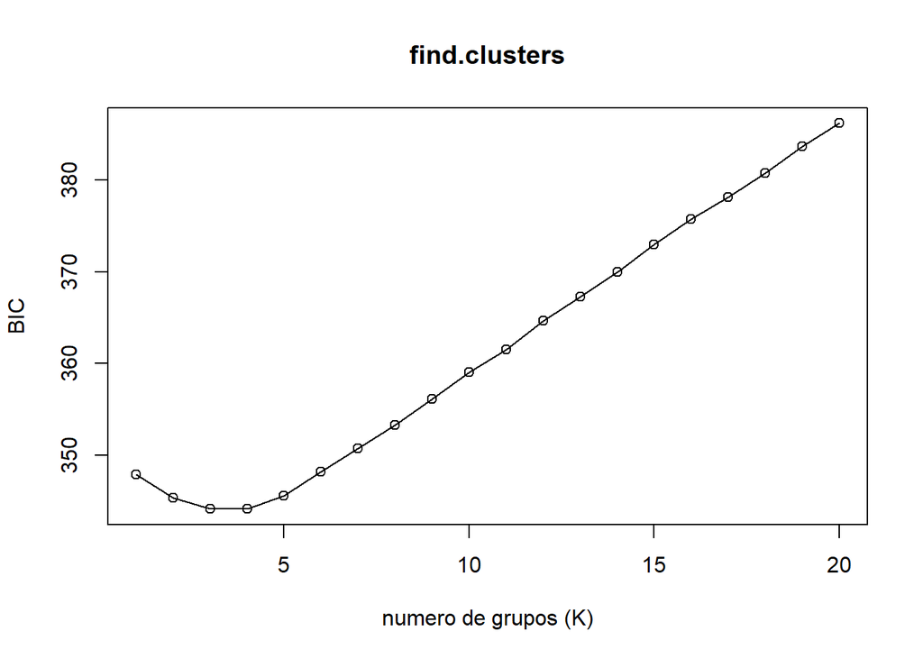

```r
# corremos find.cluster, se escoje un numero maximo de clusters
grp <- find.clusters(vcf_chambers, max.n.clust = 20, n.pca = 70, choose = FALSE, stat = "BIC", method = "kmeans")

plot(grp$Kstat, type = "o", xlab = "numero de grupos (K)",
     ylab = "BIC",
     main = "find.clusters")
```

```r
# guardamos los resultados de agrupamiento
grupos_formados <- as.data.frame(grp$grp)
write.csv(grupos_formados, "../outputs/grupos_formados_find.clusters_Chambers_AX.csv")
```

## Identificamos PC

```r
# corremos dapc con los grupos formados
dapc1 <- dapc(vcf_chambers, grp$grp, n.pca = 70, n.da = 3)

temp <- optim.a.score(dapc1)
```

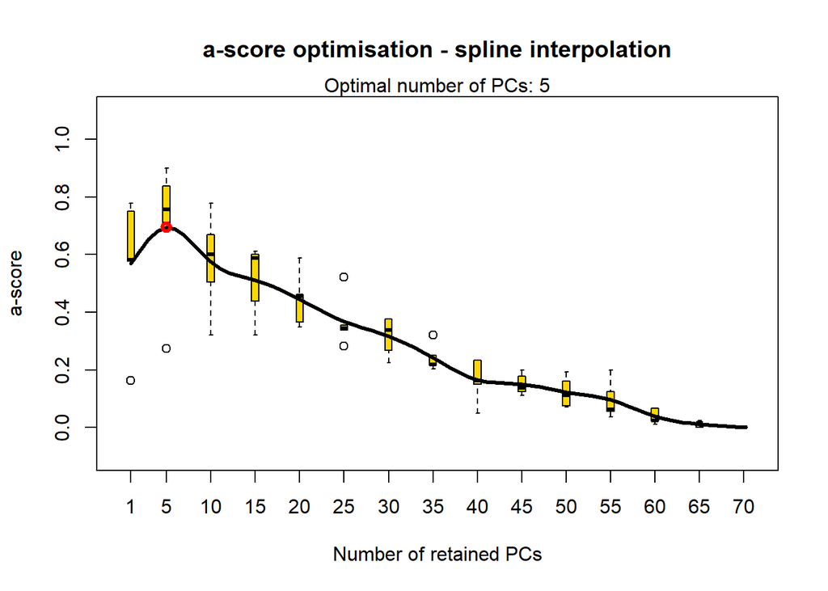

Los primero 5 pca son los optimos.

```r
# corremos dapc con los grupos formados
dapc1 <- dapc(vcf_chambers, grp$grp, n.pca = 5, n.da = 3)

dapc1
```

```
##  #################################################
##  # Discriminant Analysis of Principal Components #
##  #################################################
## class: dapc
## $call: dapc.genlight(x = vcf_chambers, pop = grp$grp, n.pca = 5, n.da = 3)
##
## $n.pca: 5 first PCs of PCA used
## $n.da: 3 discriminant functions saved
## $var (proportion of conserved variance): 0.251
##
## $eig (eigenvalues): 1602 919.9 539.5 50.33  vector    length content
## 1 $eig      4      eigenvalues
## 2 $grp      75     prior group assignment
## 3 $prior    5      prior group probabilities
## 4 $assign   75     posterior group assignment
## 5 $pca.cent 1813   centring vector of PCA
## 6 $pca.norm 1813   scaling vector of PCA
## 7 $pca.eig  74     eigenvalues of PCA
##
##   data.frame    nrow ncol content
## 1 $tab          75   5    retained PCs of PCA
## 2 $means        5    5    group means
## 3 $loadings     5    3    loadings of variables
## 4 $ind.coord    75   3    coordinates of individuals (principal components)
## 5 $grp.coord    5    3    coordinates of groups
## 6 $posterior    75   5    posterior membership probabilities
## 7 $pca.loadings 1813 5    PCA loadings of original variables
## 8 $var.contr    1813 3    contribution of original variables
```

```r
myCol <- c("darkblue","purple","green","orange","red","blue")

scatter(dapc1, scree.da=T, bg="white",scree.pca=TRUE, pch=20, cell=0, cstar=0, col=myCol, solid=.4,
cex=3,clab=0, leg=TRUE, txt.leg=paste("Cluster",1:6))
```

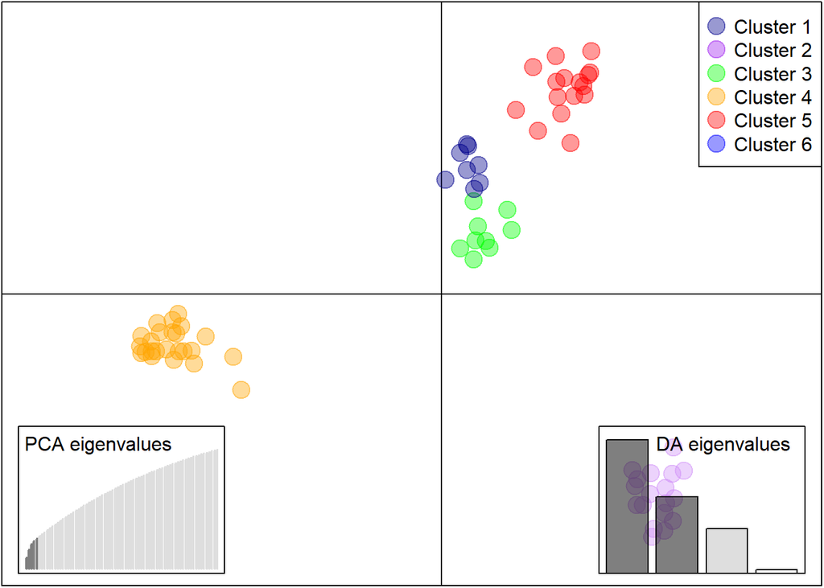

```r
scatter(dapc1,1,1, col=myCol, bg="white",
scree.da=FALSE, legend=TRUE, solid=.4)
```

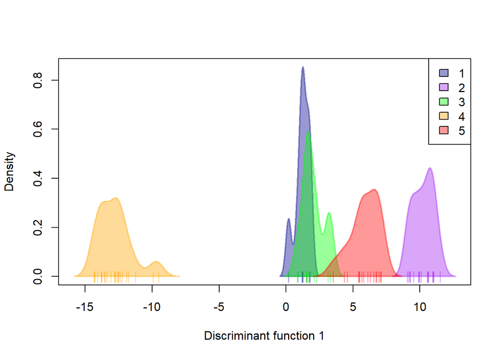

## Agregamos categorias daño

```r
# cargamos los datos de las categorias de daño
meta <- read.table("../outputs/pop_Fenotype_APAECCCA.txt", header=TRUE, sep="\t")  # Si está separado por tabulaciones

pop(vcf_chambers) <- meta$suv_damozo
```

## Cross validation

```r
# xvalDAPC r
paj<-xvalDapc(tab(vcf_chambers,NA.method="mean"), pop(vcf_chambers))
```

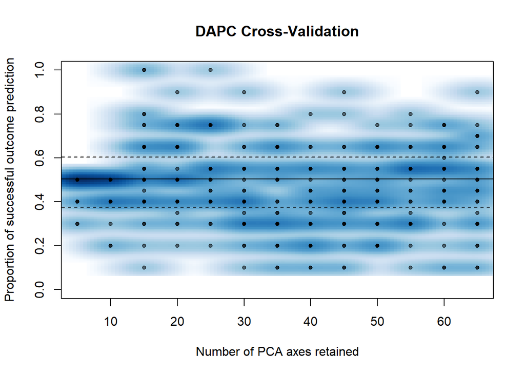

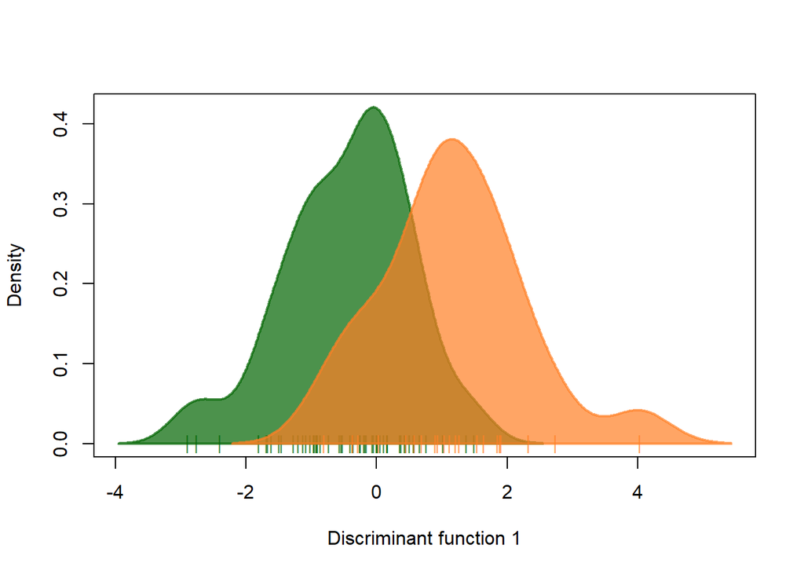

```r
plotdapc <- scatter(paj$DAPC, mstree = T, clabel = T, lwd = 2, grid=T, cex=3,
                    cleg = 0.80, posi.da = "bottomleft", col = c("darkgreen","chocolate1")  )
```

Summary Categorias

```r
#
summary(paj)
```

```
##                                                    Length Class      Mode
## Cross-Validation Results                            2     data.frame list
## Median and Confidence Interval for Random Chance    3     -none-     numeric
## Mean Successful Assignment by Number of PCs of PCA 13     -none-     numeric
## Number of PCs Achieving Highest Mean Success        1     -none-     character
## Root Mean Squared Error by Number of PCs of PCA    13     -none-     numeric
## Number of PCs Achieving Lowest MSE                  1     -none-     character
## DAPC                                               19     dapc       list
```

```r
paj[2:6]
```

```
## $`Median and Confidence Interval for Random Chance`
##      2.5%       50%     97.5%
## 0.3716931 0.5039683 0.6031746
##
## $`Mean Successful Assignment by Number of PCs of PCA`
##         5        10        15        20        25        30        35        40
## 0.4766667 0.4466667 0.5416667 0.5333333 0.5600000 0.4233333 0.4283333 0.3850000
##        45        50        55        60        65
## 0.4283333 0.4366667 0.4650000 0.5033333 0.4683333
##
## $`Number of PCs Achieving Highest Mean Success`
## [1] "25"
##
## $`Root Mean Squared Error by Number of PCs of PCA`
##         5        10        15        20        25        30        35        40
## 0.5263079 0.5597619 0.5022450 0.4929503 0.4745173 0.6001389 0.6009021 0.6384225
##        45        50        55        60        65
## 0.5982614 0.5848077 0.5589425 0.5237684 0.5645795
##
## $`Number of PCs Achieving Lowest MSE`
## [1] "25"
```

Los PC que mejor expican son 25

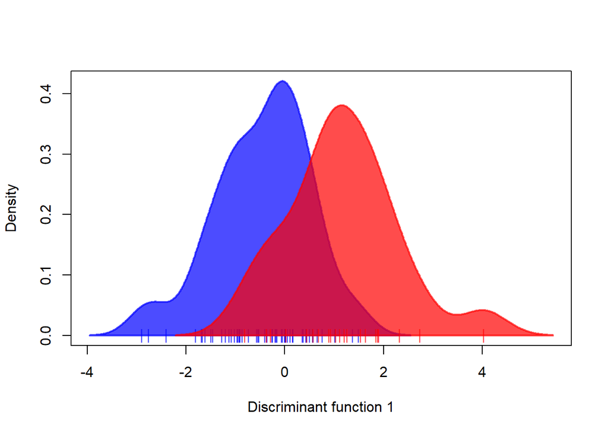

```r
# corremos dapc con los grupos formados
dapc1 <- dapc(vcf_chambers,pop(vcf_chambers), var.contrib = TRUE, n.pca = 25, n.da = 3)
scatter(dapc1)
```

```r
dapc1$var*100
```

```
## [1] 55.45955
```

```r
dapc1
```

```
##  #################################################
##  # Discriminant Analysis of Principal Components #
##  #################################################
## class: dapc
## $call: dapc.genlight(x = vcf_chambers, pop = pop(vcf_chambers), n.pca = 25,
##     n.da = 3, var.contrib = TRUE)
##
## $n.pca: 25 first PCs of PCA used
## $n.da: 1 discriminant functions saved
## $var (proportion of conserved variance): 0.555
##
## $eig (eigenvalues): 40.08  vector    length content
## 1 $eig      1      eigenvalues
## 2 $grp      75     prior group assignment
## 3 $prior    2      prior group probabilities
## 4 $assign   75     posterior group assignment
## 5 $pca.cent 1813   centring vector of PCA
## 6 $pca.norm 1813   scaling vector of PCA
## 7 $pca.eig  74     eigenvalues of PCA
##
##   data.frame    nrow ncol content
## 1 $tab          75   25   retained PCs of PCA
## 2 $means        2    25   group means
## 3 $loadings     25   1    loadings of variables
## 4 $ind.coord    75   1    coordinates of individuals (principal components)
## 5 $grp.coord    2    1    coordinates of groups
## 6 $posterior    75   2    posterior membership probabilities
## 7 $pca.loadings 1813 25   PCA loadings of original variables
## 8 $var.contr    1813 1    contribution of original variables
```

# Samples Chambers sin SRX y Aire purificado

A paritr del vcf de SNPs neutros, se seleccionaron solamente las muestras de AE (Aire Ecologia), CC (moderado de ozono), CA (contingencia de ozono). Con ellas se creo un objeto genlight. 56 muestras con 1,813 SNPs

## Creamos un objeto Genlight

```r
########## dapc categorias de daño #####
vcfR_chambers2 <- read.vcfR("../../../../VCF/GBSM_Fenotype_AECCCA.recode.vcf")
```

```
## Scanning file to determine attributes.
## File attributes:
##   meta lines: 14
##   header_line: 15
##   variant count: 1813
##   column count: 65
## Meta line 14 read in.
## All meta lines processed.
## gt matrix initialized.
## Character matrix gt created.
##   Character matrix gt rows: 1813
##   Character matrix gt cols: 65
##   skip: 0
##   nrows: 1813
##   row_num: 0
## Processed variant 1000Processed variant: 1813
## All variants processed
```

```r
vcf_chambers2<-vcfR2genlight(vcfR_chambers2)
vcf_chambers2
```

```
##  /// GENLIGHT OBJECT /////////
##
##  // 56 genotypes,  1,813 binary SNPs, size: 368.3 Kb
##  2671 (2.63 %) missing data
##
##  // Basic content
##    @gen: list of 56 SNPbin
##
##  // Optional content
##    @ind.names:  56 individual labels
##    @loc.names:  1813 locus labels
##    @chromosome: factor storing chromosomes of the SNPs
##    @position: integer storing positions of the SNPs
##    @other: a list containing: elements without names
```

## Identificamos clusters

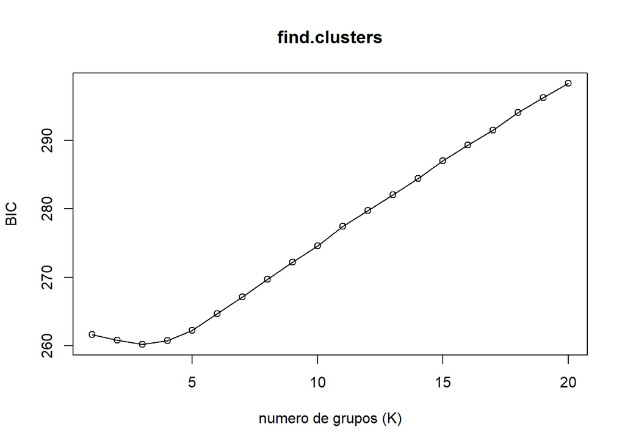

```r
# corremos find.cluster, se escoje un numero maximo de clusters
grp <- find.clusters(vcf_chambers2, max.n.clust = 20, n.pca = 70, choose = FALSE, stat = "BIC", method = "kmeans")

plot(grp$Kstat, type = "o", xlab = "numero de grupos (K)",
     ylab = "BIC",
     main = "find.clusters")
```

```r
# guardamos los resultados
grupos_formados <- as.data.frame(grp$grp)
write.csv(grupos_formados, "../outputs/grupos_formados_find.clusters_Chambers_AXAP.csv")
```

## Identificamos Pcs

```r
# corremos dapc con los grupos formados
dapc2 <- dapc(vcf_chambers2, grp$grp, n.pca = 70, n.da = 3)

temp <- optim.a.score(dapc2)
```

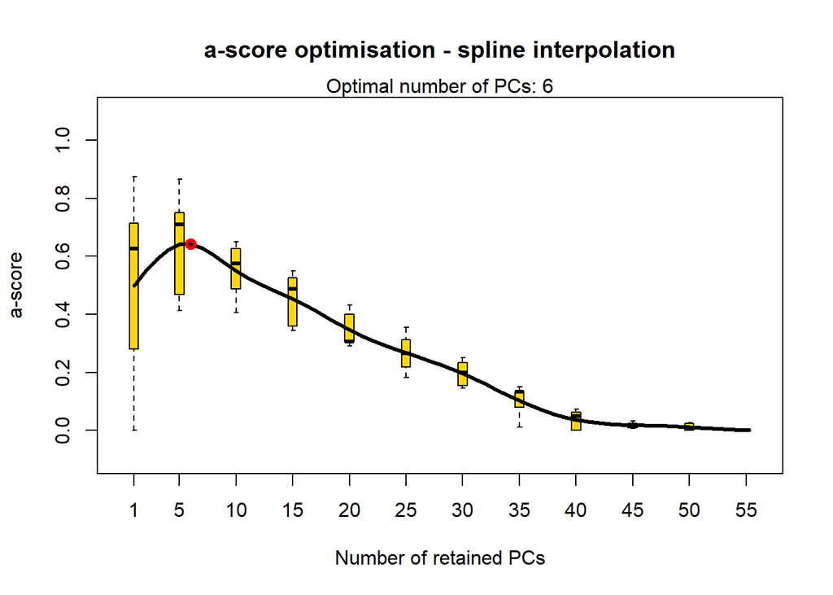

```r
# corremos dapc con los grupos formados
dapc2 <- dapc(vcf_chambers2, grp$grp, n.pca = 5, n.da = 3)

dapc2
```

```
##  #################################################
##  # Discriminant Analysis of Principal Components #
##  #################################################
## class: dapc
## $call: dapc.genlight(x = vcf_chambers2, pop = grp$grp, n.pca = 5, n.da = 3)
##
## $n.pca: 5 first PCs of PCA used
## $n.da: 3 discriminant functions saved
## $var (proportion of conserved variance): 0.27
##
## $eig (eigenvalues): 1232 819.4 505.6 64.76  vector    length content
## 1 $eig      4      eigenvalues
## 2 $grp      56     prior group assignment
## 3 $prior    5      prior group probabilities
## 4 $assign   56     posterior group assignment
## 5 $pca.cent 1813   centring vector of PCA
## 6 $pca.norm 1813   scaling vector of PCA
## 7 $pca.eig  55     eigenvalues of PCA
##
##   data.frame    nrow ncol content
## 1 $tab          56   5    retained PCs of PCA
## 2 $means        5    5    group means
## 3 $loadings     5    3    loadings of variables
## 4 $ind.coord    56   3    coordinates of individuals (principal components)
## 5 $grp.coord    5    3    coordinates of groups
## 6 $posterior    56   5    posterior membership probabilities
## 7 $pca.loadings 1813 5    PCA loadings of original variables
## 8 $var.contr    1813 3    contribution of original variables
```

```r
myCol <- c("darkblue","purple","green","orange","red","blue")

scatter(dapc2, scree.da=T, bg="white",scree.pca=TRUE, pch=20, cell=0, cstar=0, col=myCol, solid=.4,
cex=3,clab=0, leg=TRUE, txt.leg=paste("Cluster",1:6))
```

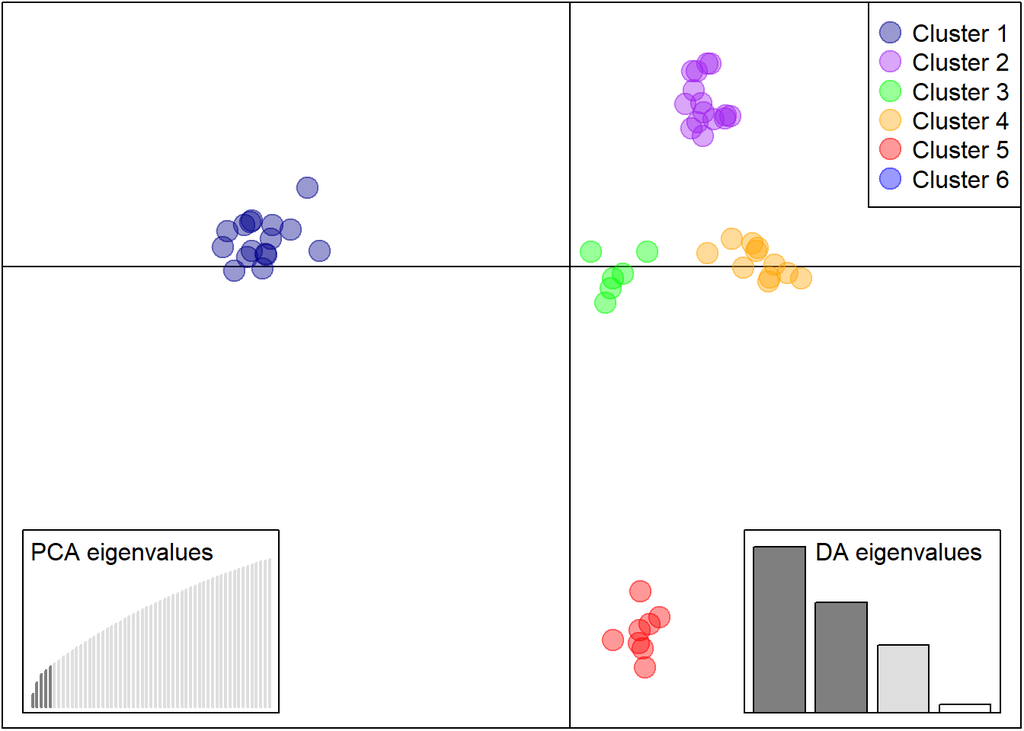

```r
scatter(dapc2,1,1, col=myCol, bg="white",
scree.da=FALSE, legend=TRUE, solid=.4)
```

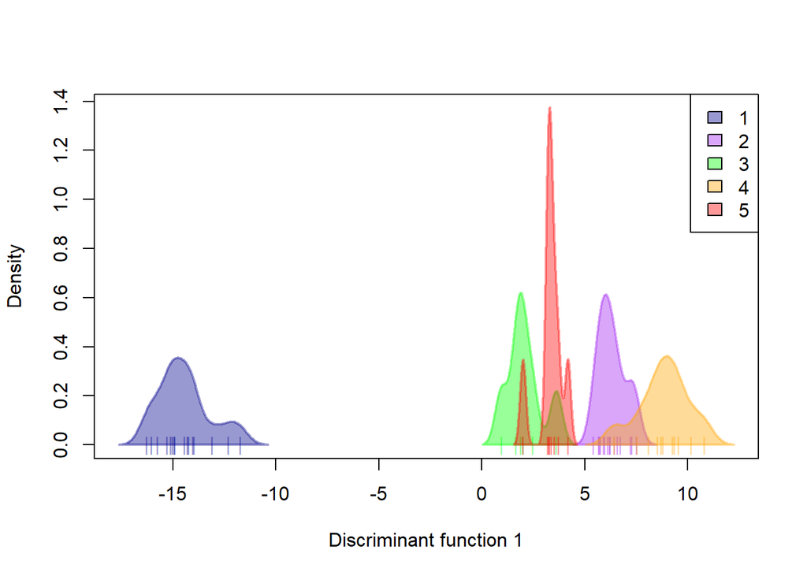

## Agregamos Categorias de daño

```r
# cargamos los datos de las categorias de daño
meta <- read.table("../outputs/pop_Fenotype_AECCCA.txt", header=TRUE, sep="\t")  # Si está separado por tabulaciones

pop(vcf_chambers2) <- meta$suv_damozo
```

## Cross Validation

```r
# xvalDAPC r
paj<-xvalDapc(tab(vcf_chambers2,NA.method="mean"), pop(vcf_chambers2))
```

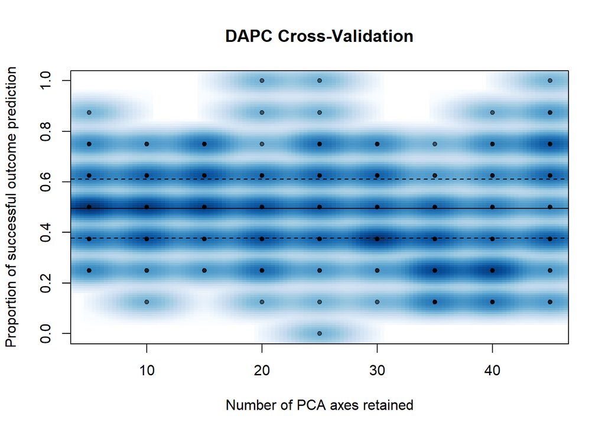

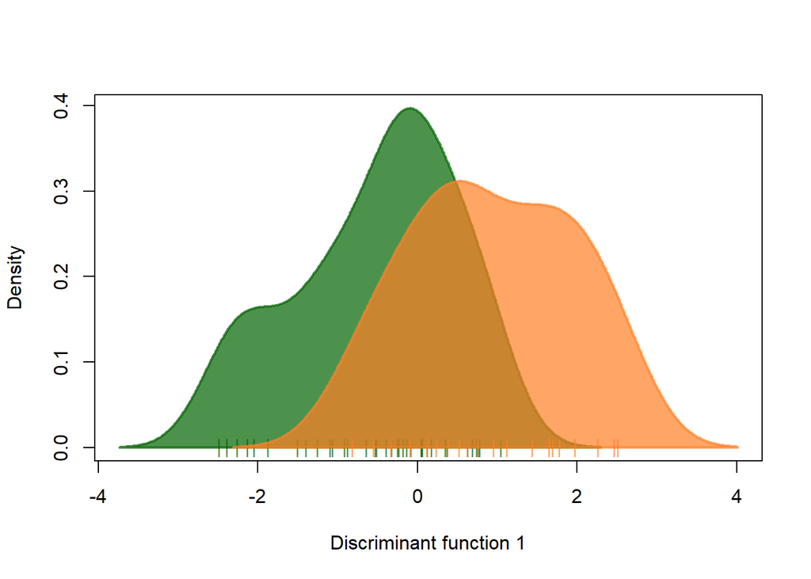

```r
plotdapc <- scatter(paj$DAPC, mstree = T, clabel = T, lwd = 2, grid=T, cex=3,
                    cleg = 0.80, posi.da = "bottomleft", col = c("darkgreen","chocolate1")  )
```

```r
summary(paj)
```

```
##                                                    Length Class      Mode
## Cross-Validation Results                            2     data.frame list
## Median and Confidence Interval for Random Chance    3     -none-     numeric
## Mean Successful Assignment by Number of PCs of PCA  9     -none-     numeric
## Number of PCs Achieving Highest Mean Success        1     -none-     character
## Root Mean Squared Error by Number of PCs of PCA     9     -none-     numeric
## Number of PCs Achieving Lowest MSE                  1     -none-     character
## DAPC                                               19     dapc       list
```

```r
paj[2:6]
```

```
## $`Median and Confidence Interval for Random Chance`
##      2.5%       50%     97.5%
## 0.3777778 0.4944444 0.6111111
##
## $`Mean Successful Assignment by Number of PCs of PCA`
##         5        10        15        20        25        30        35        40
## 0.5125000 0.4791667 0.5375000 0.4708333 0.5250000 0.4708333 0.3583333 0.3958333
##        45
## 0.5541667
##
## $`Number of PCs Achieving Highest Mean Success`
## [1] "45"
##
## $`Root Mean Squared Error by Number of PCs of PCA`
##         5        10        15        20        25        30        35        40
## 0.5097998 0.5395793 0.4835847 0.5622685 0.5214163 0.5510407 0.6606499 0.6394171
##        45
## 0.4984351
##
## $`Number of PCs Achieving Lowest MSE`
## [1] "15"
```

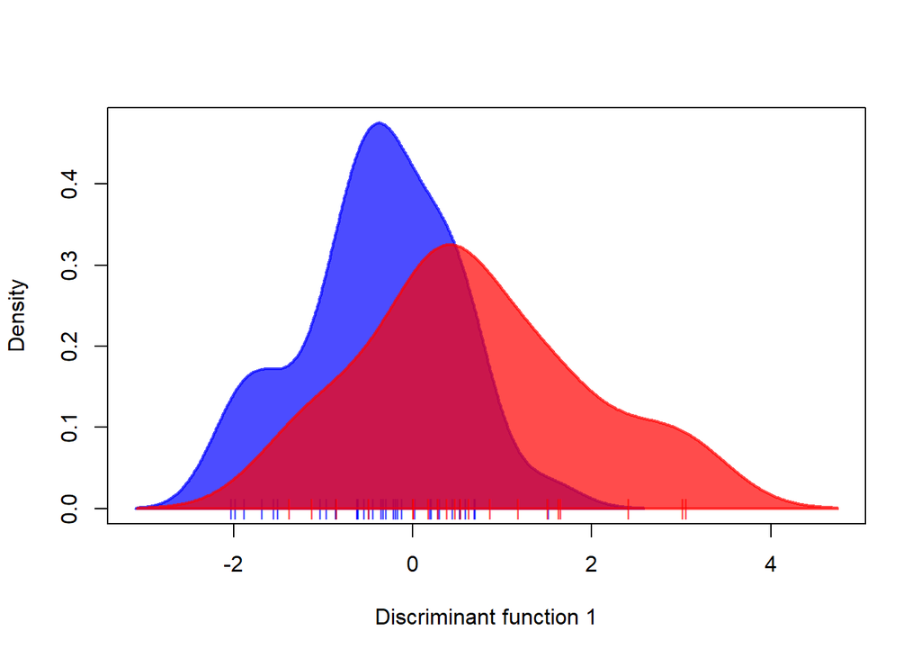

```r
# corremos dapc con los grupos formados
dapc2 <- dapc(vcf_chambers2,pop(vcf_chambers2), var.contrib = TRUE, n.pca = 10, n.da = 3)
scatter(dapc2)
```

```r
dapc2$var*100
```

```
## [1] 37.87078
```

```r
dapc2
```

```
##  #################################################
##  # Discriminant Analysis of Principal Components #
##  #################################################
## class: dapc
## $call: dapc.genlight(x = vcf_chambers2, pop = pop(vcf_chambers2), n.pca = 10,
##     n.da = 3, var.contrib = TRUE)
##
## $n.pca: 10 first PCs of PCA used
## $n.da: 1 discriminant functions saved
## $var (proportion of conserved variance): 0.379
##
## $eig (eigenvalues): 15.17  vector    length content
## 1 $eig      1      eigenvalues
## 2 $grp      56     prior group assignment
## 3 $prior    2      prior group probabilities
## 4 $assign   56     posterior group assignment
## 5 $pca.cent 1813   centring vector of PCA
## 6 $pca.norm 1813   scaling vector of PCA
## 7 $pca.eig  55     eigenvalues of PCA
##
##   data.frame    nrow ncol content
## 1 $tab          56   10   retained PCs of PCA
## 2 $means        2    10   group means
## 3 $loadings     10   1    loadings of variables
## 4 $ind.coord    56   1    coordinates of individuals (principal components)
## 5 $grp.coord    2    1    coordinates of groups
## 6 $posterior    56   2    posterior membership probabilities
## 7 $pca.loadings 1813 10   PCA loadings of original variables
## 8 $var.contr    1813 1    contribution of original variables
```

# DAPC interactivo

```r
# adegenetServer(what = "DAPC")
```